# Lecture

## Machine Learning problems with sequential data

| Retail goods sales | Historical sales | Sales next week |
| --- | --- | --- |
| Stock prices | Historical prices | Price / spread next minute |
| Transactions | Drugstore -> Petrol station -> ATM | Fraud |

## Deep Learning problems with sequential data

| Speech recognition | Speech | Text |
| --- | --- | --- |
| Sentiment classification | Text | Label |
| Machine translation | Text in one language | Text in other language |
| Video activity recognition | Video | Label |

Note the differences in input/output size and relations

## ML regression

| feature 1 | feature 2 | feature 3 | $\ldots$ | feature k | target |
| --- | --- | --- | --- | --- | --- |
| $x_{11}$ | $x_{12}$ | $x_{13}$ | $\ldots$ | $x_{1k}$ | $y_1$ |
| $x_{21}$ | $x_{22}$ | $x_{23}$ | $\ldots$ | $x_{2k}$ | $y_2$ |
| $x_{31}$ | $x_{32}$ | $x_{33}$ | $\ldots$ | $x_{3k}$ | $y_3$ |
| $\ldots$ | $\ldots$ | $\ldots$ | $\ldots$ | $\ldots$ | $\ldots$ |
| $x_{n1}$ | $x_{n2}$ | $x_{n3}$ | $\ldots$ | $x_{nk}$ | $y_n$ |

- Regularized linear regression $$ \arg\min_\theta \| y - X \theta \|^2 + \lambda_1 \| \theta \|_1 + \lambda_2 \| \theta \|_2 $$
- Gradient boosting $$ F_{m+1}(x_i) = F_m(x_i) + h_m(x_i) \approx y_i $$

## ML regression for time series forecasting

| feature 1 | feature 2 | feature 3 | $\ldots$ | feature k | target |
| --- | --- | --- | --- | --- | --- |
| $x_{11}$ | $x_{12}$ | $x_{13}$ | $\ldots$ | $x_{1k}$ | $y_1$ |
| $x_{21}$ | $x_{22}$ | $x_{23}$ | $\ldots$ | $x_{2k}$ | $y_2$ |
| $x_{31}$ | $x_{32}$ | $x_{33}$ | $\ldots$ | $x_{3k}$ | $y_3$ |
| $\ldots$ | $\ldots$ | $\ldots$ | $\ldots$ | $\ldots$ | $\ldots$ |
| $x_{n1}$ | $x_{n2}$ | $x_{n3}$ | $\ldots$ | $x_{nk}$ | $y_n$ |

- Take the series history $y_t, y_{t-1}, y_{t-2}, \ldots$
- Add external dynamic data $x_{t1}, x_{t2}, \ldots, x_{(t-1)1}, x_{(t-1)2}, \ldots$
- Add features like differences, combinations, rolling means, meadians, stds, etc
- Add encoded categorical features like day of week, holidays
- Add static features like classes
- Apply regression to $y_{t+1}$

## ML regression for time series forecasting

- External dynamic features was only partially available in classic time series

[figure not shown]

- External static features was not available in classic time series

```python
import numpy as np
import pandas as pd

import IPython.display as dp
import matplotlib.pyplot as plt
import seaborn as sns

dp.set_matplotlib_formats("retina")
sns.set(style="whitegrid", font_scale=1.5)
sns.despine()

%matplotlib inline
```

```python
from darts import TimeSeries
import darts.datasets as ds
import scipy.stats as sts
import statsmodels.api as sm
import statsmodels.tsa.api as tsa
from darts.utils.statistics import plot_acf
```

```python
from darts import concatenate
```

```python
from astsadata import cmort as cmort_pd, part as part_pd, tempr as tempr_pd
```

[output not shown]

[output cut: 19 more lines]

```python
cmort = TimeSeries.from_series(
    cmort_pd["value"].rename("mort").set_axis(
        pd.date_range(
            cmort_pd.index[0].start_time.date(),
            periods=len(cmort_pd),
            freq="W-MON",
            inclusive="both"
        )
    ).resample("M").mean()
)
part = TimeSeries.from_series(
    part_pd["value"].rename("part").set_axis(
        pd.date_range(
            part_pd.index[0].start_time.date(),
            periods=len(part_pd),
            freq="W-MON",
            inclusive="both"
        )
    ).resample("M").mean()
)
tempr = TimeSeries.from_series(
    tempr_pd["value"].rename("temp").set_axis(
        pd.date_range(
            tempr_pd.index[0].start_time.date(),
            periods=len(tempr_pd),
            freq="W-MON",
            inclusive="both"
        )
    ).resample("M").mean()
)
```

```python
cmort_train, cmort_test = cmort.split_before(pd.Timestamp("1978-01-01"))
part_cov, _ = part.split_before(pd.Timestamp("1978-01-01"))
temp_cov = tempr
```

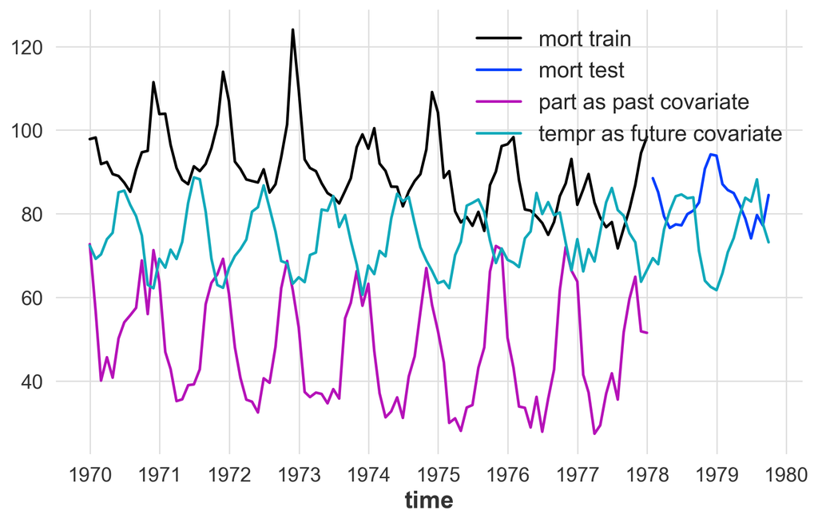

```python
fig, ax = plt.subplots(figsize=(10,6))
cmort_train.plot(ax=ax, label="mort train")
cmort_test.plot(ax=ax, label="mort test")
part_cov.plot(ax=ax, label="part as past covariate")
temp_cov.plot(ax=ax, label="tempr as future covariate")
```

```python
from darts.models import LinearRegressionModel, RegressionModel, RandomForest, XGBModel, CatBoostModel
```

```python
from darts.metrics import mape
```

```python
model = LinearRegressionModel(
    lags=[-1, -2, -3, -4, -5, -6],
    output_chunk_length=20,
)
model.fit(cmort_train);
pred = model.predict(20)
```

```python
model_past = LinearRegressionModel(
    lags=[-1, -2, -3, -4, -5, -6],
    lags_past_covariates=[-1, -2, -3, -4, -5, -6],
    output_chunk_length=20,
)
model_past.fit(cmort_train, past_covariates=part_cov);
pred_past = model_past.predict(20)
```

```python
model_future = LinearRegressionModel(
    lags=[-1, -2, -3, -4, -5, -6],
    lags_future_covariates=[0, -1, -2, -3, -4, -5, -6],
    output_chunk_length=20,
)
model_future.fit(cmort_train, future_covariates=temp_cov);
pred_future = model_future.predict(20)
```

```python
model_past_future = LinearRegressionModel(
    lags=[-1, -2, -3, -4, -5, -6],
    lags_past_covariates=[-1, -2, -3, -4, -5, -6],
    lags_future_covariates=[0, -1, -2, -3, -4, -5, -6],
    output_chunk_length=20,
)
model_past_future.fit(cmort_train, past_covariates=part_cov, future_covariates=temp_cov);
pred_past_future = model_past_future.predict(20)
```

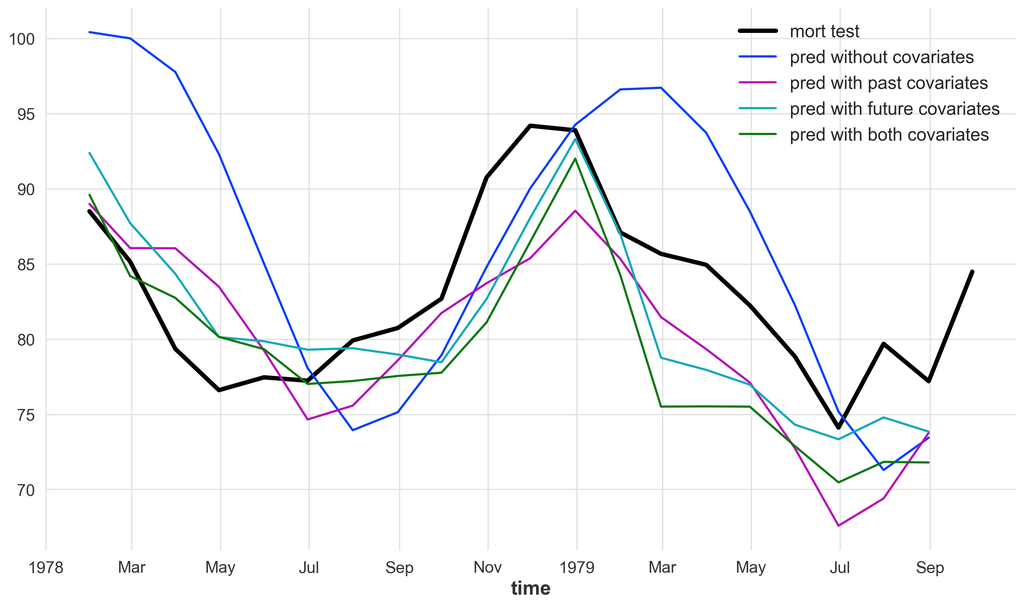

```python
fig, ax = plt.subplots(figsize=(16,9))
cmort_test.plot(ax=ax, lw=4, label="mort test")
pred.plot(ax=ax, label="pred without covariates")
pred_past.plot(ax=ax, label="pred with past covariates")
pred_future.plot(ax=ax, label="pred with future covariates")
pred_past_future.plot(ax=ax, label="pred with both covariates")
```

```python
mape(
    [cmort_test, cmort_test, cmort_test, cmort_test],
    [pred, pred_past, pred_future, pred_past_future]
)
```

```
[8.937341507111249, 5.518518759087556, 4.408916516691464, 5.590476275937467]
```

## Cross-validation

[figure not shown]

- Pro: trains using latest data
- Con: no idea how model performs out-of-time

## Cross-validation of time series (out-of-time)

[figure not shown]

- Pro: model building takes into account ability to predict out-of-time
- Con: validation set is not random

```python
model = LinearRegressionModel(
    lags=[-1, -2, -3, -4, -5, -6],
    lags_future_covariates=[0, -1, -2, -3, -4, -5, -6],
)
historical_forecasts = model.historical_forecasts(
    cmort_train, future_covariates=temp_cov, train_length=36, forecast_horizon=12, stride=12, last_points_only=False,
);
```

```
`enable_optimization=True` is ignored because `retrain` is not `False` or `0`.To hide this warning, set `show_warnings=False` or `enable_optimization=False`.
`enable_optimization=True` is ignored because `forecast_horizon > model.output_chunk_length`.To hide this warning, set `show_warnings=False` or `enable_optimization=False`.
```

```python
[f"{forecast.start_time()} - {forecast.end_time()}, {len(forecast)} values" for forecast in historical_forecasts]
```

```
['1972-12-31 00:00:00 - 1973-11-30 00:00:00, 12 values',
 '1973-12-31 00:00:00 - 1974-11-30 00:00:00, 12 values',
 '1974-12-31 00:00:00 - 1975-11-30 00:00:00, 12 values',
 '1975-12-31 00:00:00 - 1976-11-30 00:00:00, 12 values',
 '1976-12-31 00:00:00 - 1977-11-30 00:00:00, 12 values']
```

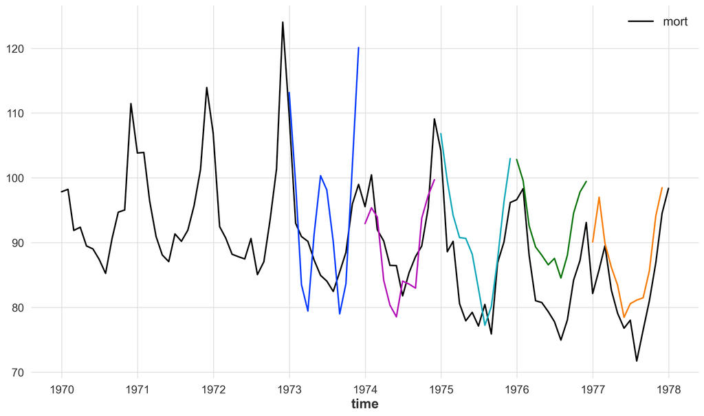

```python
fig, ax = plt.subplots(figsize=(16,9))
cmort_train.plot(ax=ax)
[forecast.plot(label=None, ax=ax) for forecast in historical_forecasts];
```

```python
model = LinearRegressionModel(
    lags=[-1, -2, -3, -4, -5, -6],
    lags_future_covariates=[0, -1, -2, -3, -4, -5, -6],
)
historical_forecasts = model.historical_forecasts(
    cmort_train, future_covariates=temp_cov, train_length=36, forecast_horizon=12, stride=6, last_points_only=False,
);
```

```
`enable_optimization=True` is ignored because `retrain` is not `False` or `0`.To hide this warning, set `show_warnings=False` or `enable_optimization=False`.
`enable_optimization=True` is ignored because `forecast_horizon > model.output_chunk_length`.To hide this warning, set `show_warnings=False` or `enable_optimization=False`.
```

```python
[f"{forecast.start_time()} - {forecast.end_time()}, {len(forecast)} values" for forecast in historical_forecasts]
```

```
['1972-12-31 00:00:00 - 1973-11-30 00:00:00, 12 values',
 '1973-06-30 00:00:00 - 1974-05-31 00:00:00, 12 values',
 '1973-12-31 00:00:00 - 1974-11-30 00:00:00, 12 values',
 '1974-06-30 00:00:00 - 1975-05-31 00:00:00, 12 values',
 '1974-12-31 00:00:00 - 1975-11-30 00:00:00, 12 values',
 '1975-06-30 00:00:00 - 1976-05-31 00:00:00, 12 values',
 '1975-12-31 00:00:00 - 1976-11-30 00:00:00, 12 values',
 '1976-06-30 00:00:00 - 1977-05-31 00:00:00, 12 values',
 '1976-12-31 00:00:00 - 1977-11-30 00:00:00, 12 values']
```

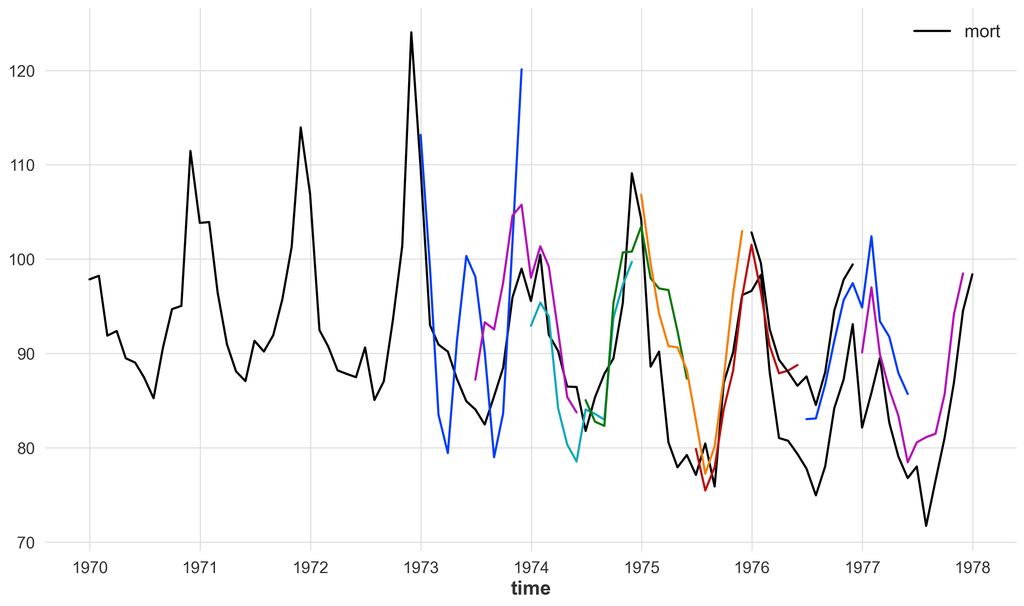

```python
fig, ax = plt.subplots(figsize=(16,9))
cmort_train.plot(ax=ax)
[forecast.plot(label=None, ax=ax) for forecast in historical_forecasts];
```

```python
model = LinearRegressionModel(
    lags=[-1, -2, -3, -4, -5, -6],
    lags_future_covariates=[0, -1, -2, -3, -4, -5, -6],
)
historical_forecasts = model.historical_forecasts(
    cmort_train, future_covariates=temp_cov, train_length=36, forecast_horizon=1, stride=1, last_points_only=True,
);
```

[output not shown]

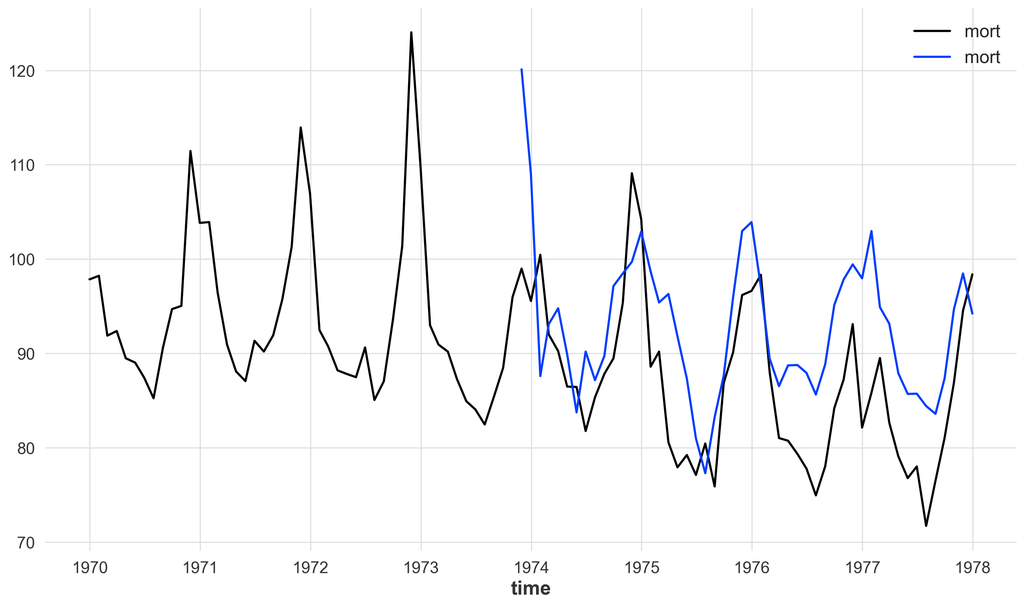

```python
fig, ax = plt.subplots(figsize=(16,9))
cmort_train.plot(ax=ax)
historical_forecasts.plot(ax=ax)
```

## Features for time series

Where to take covariates from? It would be nice to have a storage of all time series in the world and always use everything for predictions... but

- Too much features
- [Spurious correlations](https://www.tylervigen.com/spurious-correlations)
- Hard to collect

[figure not shown]

## Features for time series

[figure not shown]

```python
!pip install tsfresh
```

```
Downloading tsfresh-0.20.2-py2.py3-none-any.whl (95 kB)
   ━━━━━━━━━━━━━━━━━━━━━━━━━━━━━━━━━━━━━━━━ 95.8/95.8 kB 1.1 MB/s eta 0:00:00a 0:00:01
Downloading stumpy-1.12.0-py3-none-any.whl (169 kB)
   ━━━━━━━━━━━━━━━━━━━━━━━━━━━━━━━━━━━━━━━━ 169.1/169.1 kB 1.9 MB/s eta 0:00:00a 0:00:01
```

```python
from tsfresh.feature_extraction import extract_features
from tsfresh.feature_selection import select_features
```

```python
data = pd.concat([forecast.pd_dataframe() for forecast in historical_forecasts], axis=0)
```

```python
data["id"] = [1] * 12 + [2] * 12 + [3] * 12 + [4] * 12 + [5] * 12 + [6] * 12 + [7] * 12 + [8] * 12 + [9] * 12
data = data.reset_index()
```

```python
features = extract_features(data, column_id="id", column_sort="time")
```

```python
features.shape
```

```
(9, 783)
```

```python
features.columns
```

```
Index(['mort__variance_larger_than_standard_deviation',
       'mort__has_duplicate_max', 'mort__has_duplicate_min',
       'mort__has_duplicate', 'mort__sum_values', 'mort__abs_energy',
       'mort__mean_abs_change', 'mort__mean_change',
       'mort__mean_second_derivative_central', 'mort__median',
       ...
       'mort__fourier_entropy__bins_5', 'mort__fourier_entropy__bins_10',
       'mort__fourier_entropy__bins_100',
       'mort__permutation_entropy__dimension_3__tau_1',
       'mort__permutation_entropy__dimension_4__tau_1',
       'mort__permutation_entropy__dimension_5__tau_1',
       'mort__permutation_entropy__dimension_6__tau_1',
       'mort__permutation_entropy__dimension_7__tau_1',
       'mort__query_similarity_count__query_None__threshold_0.0',
       'mort__mean_n_absolute_max__number_of_maxima_7'],
      dtype='object', length=783)
```

```python
features
```

|  | mort__variance_larger_than_standard_deviation | mort__has_duplicate_max | mort__has_duplicate_min | mort__has_duplicate | mort__sum_values | mort__abs_energy | mort__mean_abs_change | mort__mean_change | mort__mean_second_derivative_central | mort__median | ... | mort__fourier_entropy__bins_5 | mort__fourier_entropy__bins_10 | mort__fourier_entropy__bins_100 | mort__permutation_entropy__dimension_3__tau_1 | mort__permutation_entropy__dimension_4__tau_1 | mort__permutation_entropy__dimension_5__tau_1 | mort__permutation_entropy__dimension_6__tau_1 | mort__permutation_entropy__dimension_7__tau_1 | mort__query_similarity_count__query_None__threshold_0.0 | mort__mean_n_absolute_max__number_of_maxima_7 |
| --- | --- | --- | --- | --- | --- | --- | --- | --- | --- | --- | --- | --- | --- | --- | --- | --- | --- | --- | --- | --- | --- |
| 1 | 1.0 | 0.0 | 0.0 | 0.0 | 1139.642484 | 110090.485631 | 10.641945 | 0.631589 | 1.620347 | 94.721291 | ... | 0.955700 | 1.153742 | 1.747868 | 1.418484 | 2.043192 | 2.079442 | 1.945910 | 1.791759 | NaN | 103.416014 |
| 2 | 1.0 | 0.0 | 0.0 | 0.0 | 1140.980673 | 109063.920804 | 4.433008 | -0.314952 | -0.386250 | 95.405862 | ... | 0.796312 | 1.153742 | 1.945910 | 1.695743 | 2.043192 | 2.079442 | 1.945910 | 1.791759 | NaN | 99.967709 |
| 3 | 1.0 | 0.0 | 0.0 | 0.0 | 1066.659933 | 95397.242737 | 3.874126 | 0.615210 | -0.000127 | 88.556656 | ... | 0.796312 | 1.277034 | 1.747868 | 1.332179 | 2.043192 | 2.079442 | 1.945910 | 1.791759 | NaN | 93.880375 |
| 4 | 1.0 | 0.0 | 0.0 | 0.0 | 1121.646360 | 105441.236498 | 3.635923 | 0.207136 | -0.137767 | 96.017134 | ... | 1.153742 | 1.153742 | 1.945910 | 1.168282 | 1.676988 | 1.906155 | 1.945910 | 1.791759 | NaN | 98.833182 |
| 5 | 1.0 | 0.0 | 0.0 | 0.0 | 1097.189176 | 101216.338601 | 5.028428 | -0.350706 | 0.696119 | 90.710035 | ... | 1.153742 | 1.153742 | 1.475076 | 0.897946 | 1.149060 | 1.386294 | 1.475076 | 1.560710 | NaN | 97.331424 |
| 6 | 1.0 | 0.0 | 0.0 | 0.0 | 1055.195481 | 93453.878418 | 4.086564 | 0.808375 | 0.249646 | 88.165861 | ... | 1.153742 | 1.153742 | 1.747868 | 1.220607 | 1.831020 | 1.906155 | 1.945910 | 1.791759 | NaN | 92.849997 |
| 7 | 1.0 | 0.0 | 0.0 | 0.0 | 1110.856804 | 103243.678035 | 3.197988 | -0.308378 | 0.243463 | 90.956691 | ... | 0.796312 | 1.153742 | 1.747868 | 1.418484 | 1.676988 | 1.906155 | 1.945910 | 1.791759 | NaN | 96.587148 |
| 8 | 1.0 | 0.0 | 0.0 | 0.0 | 1093.353754 | 100014.975961 | 3.751433 | 0.242822 | -0.114841 | 91.543201 | ... | 0.796312 | 1.153742 | 1.945910 | 1.279854 | 1.676988 | 1.906155 | 1.945910 | 1.791759 | NaN | 95.267194 |
| 9 | 1.0 | 0.0 | 0.0 | 0.0 | 1046.492185 | 91757.097578 | 4.131317 | 0.760571 | -0.128800 | 85.914569 | ... | 0.796312 | 1.153742 | 1.549826 | 1.168282 | 1.427061 | 1.667462 | 1.747868 | 1.791759 | NaN | 91.636422 |

9 rows × 783 columns

## Time series classification

- Challenge
- Goal: classify curves into classes
- Goal: unified approach for all problems, a one model to rule them all

| Filter | Value | Value | Value | Value |
| --- | --- | --- | --- | --- |
| Train size | Less than 100 | 100 to 500 | Greater than 500 |  |
| Test size | Less than 300 | 300 to 1000 | Greater than 1000 |  |
| Length | Less than 300 | 300 to 700 | Greater than 700 |  |
| Classes | Less than 10 | 10 to 30 | Greater than 30 |  |
| Type | Motion | Image | Sensor | ... |

## Time series classification

Challenge results:

- Approaches are heuristical in nature and consider various ideas, as time series are diverse
- Ensembles of ideas work very well and do in fact "rule them all"
- "Representations" are comparable and are faster

## Representation learning

Features from e.g. tsfresh are very informative and rich, but they are not suited for ML models, or the ML models are not well suited to draw decision boundaries in such feature spaces. The ML models work best when the space is e.g. linearly separable, thus kernel trick in SVM.

[figure not shown]

Kernel trick uses pre-defined transformations, but what if we learn optimal transformations from data? This would be representation learning, learning the optimal transformation of input features for a given task.s

## Encoder-decoder architecture

[figure not shown]

## Encoder-decoder architecture

[figure not shown]

# Webinar

```python
import pickle
```

```python
with open("returns_NASDAQ_hist_daily_06102021-091329.pkl", "rb") as f:
    data = pickle.load(f)
```

```python
data.head()
```

| Time | Ticker | Close |
| --- | --- | --- |
| 1999-11-01 | ATVI | NaN |
| 1999-11-02 | ATVI | 1.351351 |
| 1999-11-03 | ATVI | 1.754386 |
| 1999-11-04 | ATVI | 0.827586 |
| 1999-11-05 | ATVI | 5.198358 |

```python
data["Ticker"].unique()
```

```
array(['ATVI', 'ADBE', 'AMD', 'ALXN', 'ALGN', 'GOOG', 'AMZN', 'AAL',
       'AMGN', 'ADI', 'AAPL', 'AMAT', 'ASML', 'ADSK', 'ADP', 'BIDU',
       'BIIB', 'BMRN', 'BKNG', 'AVGO', 'CDNS', 'CELG', 'CERN', 'CHTR',
       'CHKP', 'CTAS', 'CSCO', 'CTXS', 'CTSH', 'CMCSA', 'COST', 'CSX',
       'CTRP', 'DLTR', 'EBAY', 'EA', 'EXPE', 'FB', 'FAST', 'FISV', 'FOX',
       'GILD', 'HAS', 'HSIC', 'IDXX', 'ILMN', 'INCY', 'INTC', 'INTU',
       'ISRG', 'JBHT', 'JD', 'KLAC', 'LRCX', 'LBTYA', 'LULU', 'MAR',
       'MXIM', 'MELI', 'MCHP', 'MU', 'MSFT', 'MDLZ', 'MNST', 'NTAP',
       'NTES', 'NFLX', 'NVDA', 'NXPI', 'ORLY', 'PCAR', 'PAYX', 'PYPL',
       'PEP', 'QCOM', 'REGN', 'ROST', 'SIRI', 'SWKS', 'SBUX', 'SYMC',
       'SNPS', 'TTWO', 'TSLA', 'TXN', 'KHC', 'TMUS', 'ULTA', 'UAL',
       'VRSN', 'VRSK', 'VRTX', 'WBA', 'WDC', 'WLTW', 'WDAY', 'WYNN',
       'XEL', 'XLNX'], dtype=object)
```

```python
data_tsla = data[data["Ticker"] == "TSLA"]
```

```python
data_tsla = data_tsla.sort_index().reset_index()
```

```python
data_tsla.head()
```

|  | Time | Ticker | Close |
| --- | --- | --- | --- |
| 0 | 2010-06-29 | TSLA | NaN |
| 1 | 2010-06-30 | TSLA | -0.251151 |
| 2 | 2010-07-01 | TSLA | -7.847251 |
| 3 | 2010-07-02 | TSLA | -12.568306 |
| 4 | 2010-07-06 | TSLA | -16.093750 |

```python
data_tsla.tail()
```

|  | Time | Ticker | Close |
| --- | --- | --- | --- |
| 2833 | 2021-09-29 | TSLA | 0.482278 |
| 2834 | 2021-09-30 | TSLA | -0.746183 |
| 2835 | 2021-10-01 | TSLA | -0.033528 |
| 2836 | 2021-10-04 | TSLA | 0.813962 |
| 2837 | 2021-10-05 | TSLA | -0.120277 |

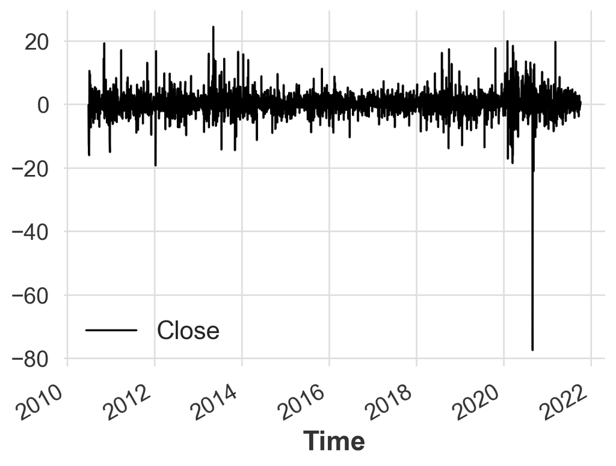

```python
data_tsla.plot(x="Time", y="Close")
```

```python
from tsfresh import extract_features, select_features
from tsfresh.utilities.dataframe_functions import roll_time_series, make_forecasting_frame
from tsfresh.utilities.dataframe_functions import impute
```

```python
data_rolled = roll_time_series(
    data_tsla,
    column_id="Ticker",
    column_sort="Time",
    max_timeshift=20,
    min_timeshift=5,
)
```

```python
data_rolled.head()
```

|  | Time | Ticker | Close | id |
| --- | --- | --- | --- | --- |
| 1995 | 2010-06-29 | TSLA | NaN | (TSLA, 2010-07-07 00:00:00) |
| 1996 | 2010-06-30 | TSLA | -0.251151 | (TSLA, 2010-07-07 00:00:00) |
| 1997 | 2010-07-01 | TSLA | -7.847251 | (TSLA, 2010-07-07 00:00:00) |
| 1998 | 2010-07-02 | TSLA | -12.568306 | (TSLA, 2010-07-07 00:00:00) |
| 1999 | 2010-07-06 | TSLA | -16.093750 | (TSLA, 2010-07-07 00:00:00) |

```python
data_rolled[(data_rolled["Time"] == pd.Timestamp("20100707"))]
```

|  | Time | Ticker | Close | id |
| --- | --- | --- | --- | --- |
| 2000 | 2010-07-07 | TSLA | -1.924271 | (TSLA, 2010-07-07 00:00:00) |
| 2006 | 2010-07-07 | TSLA | -1.924271 | (TSLA, 2010-07-08 00:00:00) |
| 2013 | 2010-07-07 | TSLA | -1.924271 | (TSLA, 2010-07-09 00:00:00) |
| 2021 | 2010-07-07 | TSLA | -1.924271 | (TSLA, 2010-07-12 00:00:00) |
| 2030 | 2010-07-07 | TSLA | -1.924271 | (TSLA, 2010-07-13 00:00:00) |
| 2040 | 2010-07-07 | TSLA | -1.924271 | (TSLA, 2010-07-14 00:00:00) |
| 2051 | 2010-07-07 | TSLA | -1.924271 | (TSLA, 2010-07-15 00:00:00) |
| 2063 | 2010-07-07 | TSLA | -1.924271 | (TSLA, 2010-07-16 00:00:00) |
| 2076 | 2010-07-07 | TSLA | -1.924271 | (TSLA, 2010-07-19 00:00:00) |
| 2090 | 2010-07-07 | TSLA | -1.924271 | (TSLA, 2010-07-20 00:00:00) |
| 2105 | 2010-07-07 | TSLA | -1.924271 | (TSLA, 2010-07-21 00:00:00) |
| 2121 | 2010-07-07 | TSLA | -1.924271 | (TSLA, 2010-07-22 00:00:00) |
| 2138 | 2010-07-07 | TSLA | -1.924271 | (TSLA, 2010-07-23 00:00:00) |
| 2156 | 2010-07-07 | TSLA | -1.924271 | (TSLA, 2010-07-26 00:00:00) |
| 2175 | 2010-07-07 | TSLA | -1.924271 | (TSLA, 2010-07-27 00:00:00) |
| 2195 | 2010-07-07 | TSLA | -1.924271 | (TSLA, 2010-07-28 00:00:00) |
| 2215 | 2010-07-07 | TSLA | -1.924271 | (TSLA, 2010-07-29 00:00:00) |
| 2235 | 2010-07-07 | TSLA | -1.924271 | (TSLA, 2010-07-30 00:00:00) |
| 2255 | 2010-07-07 | TSLA | -1.924271 | (TSLA, 2010-08-02 00:00:00) |
| 2275 | 2010-07-07 | TSLA | -1.924271 | (TSLA, 2010-08-03 00:00:00) |
| 2295 | 2010-07-07 | TSLA | -1.924271 | (TSLA, 2010-08-04 00:00:00) |

```python
X = extract_features(
    data_rolled.drop("Ticker", axis=1).fillna(0),
    column_id="id",
    column_sort="Time",
    column_value="Close",
    impute_function=impute,
    show_warnings=False
)
```

```python
X.head()
```

|  |  | Close__variance_larger_than_standard_deviation | Close__has_duplicate_max | Close__has_duplicate_min | Close__has_duplicate | Close__sum_values | Close__abs_energy | Close__mean_abs_change | Close__mean_change | Close__mean_second_derivative_central | Close__median | ... | Close__fourier_entropy__bins_5 | Close__fourier_entropy__bins_10 | Close__fourier_entropy__bins_100 | Close__permutation_entropy__dimension_3__tau_1 | Close__permutation_entropy__dimension_4__tau_1 | Close__permutation_entropy__dimension_5__tau_1 | Close__permutation_entropy__dimension_6__tau_1 | Close__permutation_entropy__dimension_7__tau_1 | Close__query_similarity_count__query_None__threshold_0.0 | Close__mean_n_absolute_max__number_of_maxima_7 |
| --- | --- | --- | --- | --- | --- | --- | --- | --- | --- | --- | --- | --- | --- | --- | --- | --- | --- | --- | --- | --- | --- | --- |
| TSLA | 2010-07-07 | 1.0 | 0.0 | 0.0 | 0.0 | -38.684729 | 482.316353 | 6.052646 | -0.384854 | 1.802579 | -4.885761 | ... | 1.039721 | 1.386294 | 1.386294 | 0.562335 | 0.636514 | 0.693147 | -0.000000 | 2.708050 | 0.0 | 4.215944 |
|  | 2010-07-08 | 1.0 | 0.0 | 0.0 | 0.0 | -28.178400 | 592.699305 | 7.115638 | 1.751055 | 1.268175 | -1.924271 | ... | 1.039721 | 1.039721 | 1.386294 | 0.950271 | 1.039721 | 1.098612 | 0.693147 | -0.000000 | 0.0 | 4.215944 |
|  | 2010-07-09 | 1.0 | 0.0 | 0.0 | 0.0 | -28.522043 | 592.817395 | 7.649114 | -0.049092 | -0.883235 | -1.133957 | ... | 0.950271 | 1.332179 | 1.609438 | 1.242453 | 1.332179 | 1.386294 | 1.098612 | 0.693147 | 0.0 | 7.076386 |
|  | 2010-07-12 | 1.0 | 0.0 | 0.0 | 0.0 | -30.533537 | 596.863504 | 6.901457 | -0.251437 | -0.101193 | -1.924271 | ... | 1.054920 | 1.054920 | 1.332179 | 1.153742 | 1.560710 | 1.609438 | 1.386294 | 1.098612 | 0.0 | 7.327863 |
|  | 2010-07-13 | 1.0 | 0.0 | 0.0 | 0.0 | -24.140575 | 637.733466 | 7.068457 | 0.710329 | 0.540975 | -1.133957 | ... | 1.011404 | 1.242453 | 1.791759 | 1.213008 | 1.747868 | 1.791759 | 1.609438 | 1.386294 | 0.0 | 8.192052 |

5 rows × 783 columns

```python
X.shape
```

```
(2833, 783)
```

```python
X = X.set_index(X.index.map(lambda x: x[1]), drop=True)
X.index.name = "last_date"
X.head()
```

| last_date | Close__variance_larger_than_standard_deviation | Close__has_duplicate_max | Close__has_duplicate_min | Close__has_duplicate | Close__sum_values | Close__abs_energy | Close__mean_abs_change | Close__mean_change | Close__mean_second_derivative_central | Close__median | ... | Close__fourier_entropy__bins_5 | Close__fourier_entropy__bins_10 | Close__fourier_entropy__bins_100 | Close__permutation_entropy__dimension_3__tau_1 | Close__permutation_entropy__dimension_4__tau_1 | Close__permutation_entropy__dimension_5__tau_1 | Close__permutation_entropy__dimension_6__tau_1 | Close__permutation_entropy__dimension_7__tau_1 | Close__query_similarity_count__query_None__threshold_0.0 | Close__mean_n_absolute_max__number_of_maxima_7 |
| --- | --- | --- | --- | --- | --- | --- | --- | --- | --- | --- | --- | --- | --- | --- | --- | --- | --- | --- | --- | --- | --- |
| 2010-07-07 | 1.0 | 0.0 | 0.0 | 0.0 | -38.684729 | 482.316353 | 6.052646 | -0.384854 | 1.802579 | -4.885761 | ... | 1.039721 | 1.386294 | 1.386294 | 0.562335 | 0.636514 | 0.693147 | -0.000000 | 2.708050 | 0.0 | 4.215944 |
| 2010-07-08 | 1.0 | 0.0 | 0.0 | 0.0 | -28.178400 | 592.699305 | 7.115638 | 1.751055 | 1.268175 | -1.924271 | ... | 1.039721 | 1.039721 | 1.386294 | 0.950271 | 1.039721 | 1.098612 | 0.693147 | -0.000000 | 0.0 | 4.215944 |
| 2010-07-09 | 1.0 | 0.0 | 0.0 | 0.0 | -28.522043 | 592.817395 | 7.649114 | -0.049092 | -0.883235 | -1.133957 | ... | 0.950271 | 1.332179 | 1.609438 | 1.242453 | 1.332179 | 1.386294 | 1.098612 | 0.693147 | 0.0 | 7.076386 |
| 2010-07-12 | 1.0 | 0.0 | 0.0 | 0.0 | -30.533537 | 596.863504 | 6.901457 | -0.251437 | -0.101193 | -1.924271 | ... | 1.054920 | 1.054920 | 1.332179 | 1.153742 | 1.560710 | 1.609438 | 1.386294 | 1.098612 | 0.0 | 7.327863 |
| 2010-07-13 | 1.0 | 0.0 | 0.0 | 0.0 | -24.140575 | 637.733466 | 7.068457 | 0.710329 | 0.540975 | -1.133957 | ... | 1.011404 | 1.242453 | 1.791759 | 1.213008 | 1.747868 | 1.791759 | 1.609438 | 1.386294 | 0.0 | 8.192052 |

5 rows × 783 columns

```python
y = data_tsla.set_index("Time").sort_index()['Close'].shift(-1).dropna()
```

```python
y_dummy = data_tsla.set_index("Time").sort_index()['Close'].diff().transform(lambda x: np.sign(x)).dropna()
```

```python
y_dummy
```

[output not shown]

```python
common_index = X.index.intersection(y.index)
X = X.loc[common_index]
y = y.loc[common_index]
y_dummy = y_dummy.loc[common_index]
```

```python
X_train = X[:"2018"]
X_test = X["2019":]

y_train = y[:"2018"]
y_test = y["2019":]
y_dummy_train = y_dummy[:"2018"]
```

```python
X_train_selected = select_features(X_train, y_dummy_train, ml_task="classification")
```

```python
X_test_selected = X_test[X_train_selected.columns]
```

```python
X_train_selected.shape
```

```
(2137, 57)
```

```python
from xgboost import XGBRegressor
```

```python
xgb = XGBRegressor(n_estimators=100, max_depth=3, )
```

```python
xgb.fit(X_train_selected, y_train)
```

```
XGBRegressor(base_score=None, booster=None, callbacks=None,
             colsample_bylevel=None, colsample_bynode=None,
             colsample_bytree=None, device=None, early_stopping_rounds=None,
             enable_categorical=False, eval_metric=None, feature_types=None,
             gamma=None, grow_policy=None, importance_type=None,
             interaction_constraints=None, learning_rate=None, max_bin=None,
             max_cat_threshold=None, max_cat_to_onehot=None,
             max_delta_step=None, max_depth=3, max_leaves=None,
             min_child_weight=None, missing=nan, monotone_constraints=None,
             multi_strategy=None, n_estimators=100, n_jobs=None,
             num_parallel_tree=None, random_state=None, ...)
```

```python
xgb_pred = pd.Series(xgb.predict(X_test_selected), index=X_test_selected.index)
```

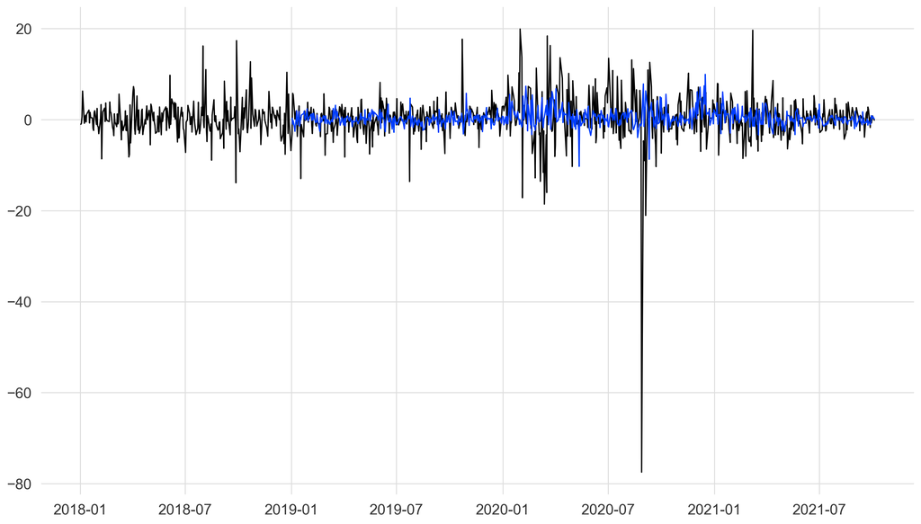

```python
fig, ax = plt.subplots(figsize=(16,9))
ax.plot(y["2018":], label="Ground Truth")
ax.plot(xgb_pred)
```

```python
from sklearn.metrics import mean_squared_error, mean_absolute_percentage_error
```

```python
mean_squared_error(y_test, xgb_pred)
```

```
28.908068725603076
```

```python
mean_squared_error(y_test, np.ones_like(y_test) * y_test.mean())
```

```
26.551338195389704
```

```python
mean_squared_error(y_test, y_test.shift(1).fillna(0))
```

```
51.086028269445585
```